# DATA 299: Data Management with dplyr

Recall, the **tidyverse** contains useful packages for managing and visualizing data such as

- dplyr
- ggplot

The package `ggplot` gives us nice functions for creating graphics. More on that later. The package `dplyr`, which is designed to help us intuitively tackle data frame manipulation tasks via a collection of *action verbs*:

| dplyr command | Description |
| --- | --- |
| `select()` | selecting columns (variables) |
| `filter()` | filter (subset) rows |
| `mutate()` | create new variables (columns) |
| `group_by()` | group the data |
| `summarize()` | summarize or aggregate the data |
| `arrange()` | sort the data |
| `join()` | joining data frames |
| `recode()` | recoding a variable |

**I encourage you to reproduce all of the results on this page in your own RStudio session.**

# The Rectangles data

Inspired by a data table of first names, I created some rectangles in my laboratory. I gave them names, handedness, dimensions, and a color. In short order I had a veritable village of rectangles. To meet this friendly lot, load them into your session:

```r
df <- read.csv("https://mphitchman.com/stats/sports/data/rectangles.csv")
```

Here’s one way to get a quick look:

```r
summary(df)
```

```
##      Name               length           width          color
##  Length:600         Min.   : 3.710   Min.   :11.50   Length:600
##  Class :character   1st Qu.: 7.530   1st Qu.:12.26   Class :character
##  Mode  :character   Median : 8.890   Median :13.02   Mode  :character
##                     Mean   : 8.933   Mean   :12.98
##                     3rd Qu.:10.320   3rd Qu.:13.65
##                     Max.   :16.130   Max.   :14.49
##                                      NA's   :8
```

The data frame has 600 rectangles and 4 variables associated with them: their `Name` (which gives name and handedness), `length`, `width`, and `color`. Notice, `Name` and `color` are categorical variables, and `length` and `width` are numerical. Notice also that `width` has a few missing values.

We will spend time discussing ways to handle missing values. One approach is to delete rows with missing values. Here, we replace missing width values with the mean width.

We can see which rows have missing width values:

```r
df[is.na(df$width),]
```

```
##             Name length width  color
## 55    Brinda (L)   9.27    NA   blue
## 56     Malia (R)   5.80    NA orange
## 189 Rayfield (R)  10.16    NA  green
## 195  Trenten (R)   9.28    NA    red
## 224    Flint (R)   7.84    NA yellow
## 252  Beckham (R)  10.18    NA  green
## 282    Dwane (R)   7.82    NA  green
## 377   Yareli (R)   6.16    NA yellow
```

and we compute the average of the recorded widths as follows:

```r
mean(df$width, na.rm=T)
```

```
## [1] 12.98125
```

We assign this average value to the missing width cells as follows:

```r
df$width[is.na(df$width)] <- mean(df$width, na.rm = T)
```

# Intro to `dplyr`

To access the functions in `dplyr`, our data management package of choice, we load the *tidyverse* into our session:

```
library(tidyverse)
```

> The key to using `dplyr` is the pipe command `|>`, which I read as “then”, followed by an action, such as `filter()` or `select()`, which we discuss below. Alternatively, the pipe command can be written as `%>%`.

For instance, if I came across the following code

```
lego |> filter(pieces > 500) |> arrange(desc(cost))
```

I would read it as follows: “take the ‘lego’ data set, **then** filter it to include just those lego sets with more than 500 pieces, and **then** arrange these sets by how how much they cost, in descending order.” Of course, the code above assumes I have a data frame entitled `lego` having columns named `pieces` and `cost`.

Recall the brief list of *dplyr* action verbs:

| dplyr command | Description |
| --- | --- |
| `select()` | selecting columns (variables) |
| `filter()` | filter (subset) rows |
| `mutate()` | create new variables (columns) |
| `group_by()` | group the data |
| `summarize()` | summarize or aggregate the data |
| `arrange()` | sort the data |
| `join()` | joining data frames |
| `recode()` | recoding a variable |

We consider these one at a time, with the rectangles data.

# Filter (rows)

We use the `filter()` action to find those rows (observations) that meet some criterion for a variable.

For instance, the following code returns all rectangles in `df` having length at least 15 and sorted by length in descending order. There are just 2!

```r
df |> filter(length >= 15) |> arrange(desc(length))
```

```
##        Name length width  color
## 1 Dasia (R)  16.13 14.48 orange
## 2   Son (R)  15.96 13.47 yellow
```

**Note**: We use the double equal signs `==` when we are searching for entries that match a particular value or character. We use a single equal sign (e.g., `x = 4`) to *assign* a value or character to a variable.

**Note**: We can filter on multiple conditions at once.

To filter on those rows in which BOTH cond1 and cond2 apply, we can write

`df |> filter(cond1 & cond2)` or `df |> filter(cond1, cond2)`.

To filter on those rows in which either cond1 or cond2 applies, we write

`df |> filter(cond1 | cond2)`

**Question**: List all rectangles that are yellow and have length at least 14

```r
df |> filter(color=="yellow", length >= 14)
```

```
##            Name length width  color
## 1 Maryellen (R)  14.68 12.60 yellow
## 2       Son (R)  15.96 13.47 yellow
## 3     Suzie (R)  14.62 12.48 yellow
```

**Question**: List all rectangles that have width greater than 14.4 or length greater than 16.

```r
df |> filter(width > 14.4 | length > 16)
```

```
##             Name length width  color
## 1   Georgina (R)   9.46 14.49  green
## 2      Odell (R)   7.89 14.44 yellow
## 3        Kya (R)   7.12 14.46 orange
## 4     Amalie (L)   8.25 14.41 orange
## 5     Bethel (L)   7.99 14.41 orange
## 6     Martez (R)   7.97 14.48  green
## 7       Earl (R)   6.75 14.41  green
## 8      Derek (L)   5.59 14.41  green
## 9      Deryl (R)   7.47 14.46  green
## 10    Jayson (R)   8.43 14.42 yellow
## 11     Dasia (R)  16.13 14.48 orange
## 12    Montie (L)  11.09 14.47    red
## 13   Garrett (R)   6.44 14.41  green
## 14 Georganna (R)   8.54 14.47    red
## 15     Regan (R)   4.59 14.48    red
```

# Separate (a column)

If I want to filter rectangles according to their handedness it would be convenient to separate a rectangle’s handedness from its name. That is, handedness should be its own column in the data frame.

The following command redefines the data frame df after separating the handedness from the name column

```r
df <- df |> separate(Name,into=c('Name','Hand'),sep=" ",remove=TRUE)
head(df,4)
```

```
##       Name Hand length width  color
## 1   Linnie  (R)  10.70 13.74 yellow
## 2    Hyrum  (L)   7.92 11.83   blue
## 3   Emmett  (R)  11.60 13.38    red
## 4 Georgina  (R)   9.46 14.49  green
```

# Unite (columns)

Incidentally, this process is reversible via the `unite()` command:

```r
df |> unite('Name',Name:Hand,sep=" ",remove=TRUE) |> slice(1:4)
```

```
##           Name length width  color
## 1   Linnie (R)  10.70 13.74 yellow
## 2    Hyrum (L)   7.92 11.83   blue
## 3   Emmett (R)  11.60 13.38    red
## 4 Georgina (R)   9.46 14.49  green
```

Notice that in the preceding code chunk I did not redefine `df` here, I simply *displayed* the result of uniting the columns, so the data frame `df` stays as defined in the code chunk above in which we separated handedness from name:

```r
head(df,4)
```

```
##       Name Hand length width  color
## 1   Linnie  (R)  10.70 13.74 yellow
## 2    Hyrum  (L)   7.92 11.83   blue
## 3   Emmett  (R)  11.60 13.38    red
## 4 Georgina  (R)   9.46 14.49  green
```

**Question**: List in alphabetical order all yellow, left-handed rectangles having length less than 7. ***

```r
df |> filter(Hand=="(L)" & color=="yellow" & length < 7) |> arrange(Name)
```

```
##      Name Hand length width  color
## 1  Joleen  (L)   5.65 12.76 yellow
## 2  Julius  (L)   5.02 13.49 yellow
## 3  Lesley  (L)   6.90 12.14 yellow
## 4 Mustafa  (L)   4.54 13.82 yellow
## 5 Rashawn  (L)   4.89 11.92 yellow
## 6    Saul  (L)   5.55 13.29 yellow
```

**Question**: Any rectangle named ‘Tom’ or ‘John’,‘Dave’, or ‘Mike’?

```r
bros = c('Tom','John','Dave','Mike')
df |> filter(Name %in% bros)
```

```
##   Name Hand length width color
## 1 Mike  (R)   4.19 13.48 green
```

That’s clearly not me. I’m left-handed. I’m also not a rectangle.

# Mutate (new columns)

The mutate command can be used to create new columns.

For instance, we can create a perimeter column and an area column from the length and width columns. I will redefine the data frame so that we carry these new columns along with us as we go.

```r
df <- df |> mutate(area = length*width,
                   perimeter = 2*length + 2*width)
```

**Question**: Find the average area of all green, left-handed rectangles.

```r
mean((df |> filter(color=="green" & Hand == '(L)'))$area)
```

```
## [1] 123.8571
```

The overall average area is 115.85, so green lefties, on average, tend to have slightly larger area.

# Select (columns)

We can `select()` certain columns to display (and choose the order in which to display them). Perhaps we just want to report the names and perimeters of the 10 largest (in terms of area) green lefties? No sweat!

```r
df |>
  filter(color=='green',Hand=='(L)') |>
  arrange(desc(area)) |>
  select(Name,perimeter) |>
  head(10)
```

```
##        Name perimeter
## 1   Stefani     54.18
## 2      Carl     52.40
## 3     Rikki     52.24
## 4     Freda     51.08
## 5      Joan     50.00
## 6      Daja     48.54
## 7     Matie     48.84
## 8  Francina     48.24
## 9    Delila     47.64
## 10     Lyla     47.48
```

# Summary statistics by group

**Task**: Create a new data frame called `df_by_color` that groups the rectangles by color and records the following:

1. how many rectangles of each color type,
2. the mean area of rectangles of each color, and
3. the standard deviation of the areas in each color group

```r
df_by_color <- df |>
  group_by(color) |>
  summarize(N=length(color),
            avg=mean(area),
            stdev=sd(area))
df_by_color
```

```
## # A tibble: 5 × 4
##   color      N   avg stdev
##   <chr>  <int> <dbl> <dbl>
## 1 blue     121  110.  27.7
## 2 green    114  116.  27.8
## 3 orange   124  118.  28.0
## 4 red      116  118.  24.5
## 5 yellow   125  117.  27.7
```

**Note**: This is a very useful thing to do. Often we will want to find the sample mean, sample size, and sample standard deviation across different groups like this.

Here’s a nice display of these summary statistics, which uses the package `kableExtra`, and also rounds the means and standard deviations to 2 decimal points:

```r
library(kableExtra)
df_by_color |>
  kbl(digits=2) |>
  kable_classic(full_width=FALSE,
                position="left")
```

| color | N | avg | stdev |
| --- | --- | --- | --- |
| blue | 121 | 110.42 | 27.73 |
| green | 114 | 116.31 | 27.82 |
| orange | 124 | 118.24 | 27.95 |
| red | 116 | 117.78 | 24.49 |
| yellow | 125 | 116.54 | 27.73 |

# Join (data frames)

We will have occasion to join two different data frames that are linked by some common variable. For instance, I failed to mention that all of our rectangles are in college, and I have a second data set that gives their year in school. Here are the first few rows of this second data frame:

```
##        Name       year
## 1    Linnie     junior
## 2     Hyrum     junior
## 3    Emmett     junior
## 4  Georgina  sophomore
## 5    Regena     junior
## 6      Duff  sophomore
## 7        Jo  sophomore
## 8  Tatianna  sophomore
## 9   Alfonzo     junior
## 10     Onie first-year
```

Good ol’ Duff!

So we have two data frames containing information about our rectangles, the original one we’ve been working with (which now has 7 columns by my count), and a second one containing name and year in college. We can join them into a single data frame, linked by *Name* as follows:

```r
df_big <- left_join(df,df2,by='Name')
```

Notice the new data frame has 8 variables. Here are the first few rows

```r
df_big |> slice(1:10)
```

```
##        Name Hand length width  color     area perimeter       year
## 1    Linnie  (R)  10.70 13.74 yellow 147.0180     48.88     junior
## 2     Hyrum  (L)   7.92 11.83   blue  93.6936     39.50     junior
## 3    Emmett  (R)  11.60 13.38    red 155.2080     49.96     junior
## 4  Georgina  (R)   9.46 14.49  green 137.0754     47.90  sophomore
## 5    Regena  (L)   9.22 13.11 yellow 120.8742     44.66     junior
## 6      Duff  (R)  10.02 12.93    red 129.5586     45.90  sophomore
## 7        Jo  (R)   8.62 13.98 yellow 120.5076     45.20  sophomore
## 8  Tatianna  (R)   7.04 13.14    red  92.5056     40.36  sophomore
## 9   Alfonzo  (R)   6.33 12.21 yellow  77.2893     37.08     junior
## 10     Onie  (R)  11.31 14.30 orange 161.7330     51.22 first-year
```

In general we have 4 options for how to join two data frames. Suppose $X$ and $Y$ are two data frames to be joined via a common column (or columns).

- `inner_join(X,Y)` only retain rows that match between $X$ and $Y$.
- `left_join(X,Y)` retain all rows from $X$, whether or not they match in $Y$.
- `right_join(X,Y)` retains all rows from $Y$, whether or not they match in X.
- `full_join(X,Y)` retains all rows from $X$ and all rows from $Y$, whether or not they match.

In our example above, the two data frames matched *exactly* via the `Name` column: every name in `df` appeared in `df2` and vice versa. All four of the join options above would return the same data frame. Let’s look at a small example to demonstrate the differences between these four options.

```r
X <- df[1:3,1:2]
Y <- data.frame(Name=df$Name[2:4],fav_num = c(8,4,1))
print(X)
```

```
##     Name Hand
## 1 Linnie  (R)
## 2  Hyrum  (L)
## 3 Emmett  (R)
```

```r
print(Y)
```

```
##       Name fav_num
## 1    Hyrum       8
## 2   Emmett       4
## 3 Georgina       1
```

```r
print(left_join(X,Y,by='Name'))
```

```
##     Name Hand fav_num
## 1 Linnie  (R)      NA
## 2  Hyrum  (L)       8
## 3 Emmett  (R)       4
```

```r
print(right_join(X,Y,by='Name'))
```

```
##       Name Hand fav_num
## 1    Hyrum  (L)       8
## 2   Emmett  (R)       4
## 3 Georgina <NA>       1
```

```r
print(inner_join(X,Y,by='Name'))
```

```
##     Name Hand fav_num
## 1  Hyrum  (L)       8
## 2 Emmett  (R)       4
```

```r
print(full_join(X,Y,by='Name'))
```

```
##       Name Hand fav_num
## 1   Linnie  (R)      NA
## 2    Hyrum  (L)       8
## 3   Emmett  (R)       4
## 4 Georgina <NA>       1
```

# Recode

Suppose that the `color` column is an artifact of old data entry practices, back when the rectangles were young. Each color actually represents a region of the US. That is, the `color` column actually tells us the region in the US in which the rectangle lives:

- blue <–> northwest
- green <–> southwest
- orange <–> midwest
- red <–> southeast
- yellow <–> northeast

We can create a new column from called `region` that re-codes the categorical variable `color` to its associated region. To do so we use `mutate()` and, you guessed it, `recode()`.

```r
df <- df |>
  mutate(region=recode(color,
                       'blue'='nw',
                       'green'='sw',
                       'orange'='mw',
                       'red'='se',
                       'yellow'='ne')
         )

kbl(df |> slice(1:8)) |> kable_paper(full_width=F)
```

We can also use the `recode()` command to edit columns. For instance, we can get rid of those annoying parentheses in the `Hand` column as follows:

```r
df <- df |>
  mutate(Hand=recode(Hand,
                       '(L)'='L',
                       '(R)'='R')
         )
kbl(df |> slice(1:8)) |> kable_paper(full_width=F)
```

| Name | Hand | length | width | color | area | perimeter | region |
| --- | --- | --- | --- | --- | --- | --- | --- |
| Linnie | R | 10.70 | 13.74 | yellow | 147.0180 | 48.88 | ne |
| Hyrum | L | 7.92 | 11.83 | blue | 93.6936 | 39.50 | nw |
| Emmett | R | 11.60 | 13.38 | red | 155.2080 | 49.96 | se |
| Georgina | R | 9.46 | 14.49 | green | 137.0754 | 47.90 | sw |
| Regena | L | 9.22 | 13.11 | yellow | 120.8742 | 44.66 | ne |
| Duff | R | 10.02 | 12.93 | red | 129.5586 | 45.90 | se |
| Jo | R | 8.62 | 13.98 | yellow | 120.5076 | 45.20 | ne |
| Tatianna | R | 7.04 | 13.14 | red | 92.5056 | 40.36 | se |

# Cut

```r
df <- df |>
  mutate(size_type = cut(area,
                    breaks = c(0,75,100,125,150,1000),
                    labels = c('tiny','small','average','large','jumbo')
                    )
         )
```

One may want to make cuts at certain *quantiles*, e.g., perhaps we want to define `tiny` to be the smallest five percent of rectangles (by area). To find this 5th percentile value, we can run

```r
quantile(df$area,.05)
```

```
##       5%
## 71.19696
```

About five percent of rectangles in this data set have area less than 71.2. Let’s check:

```r
sum(df$area < 71.2)/nrow(df)
```

```
## [1] 0.05
```

# Combining dplyr with ggplot

The packages `dplyr` and `ggplot2` are both a part of the tidyverse and can work together. For instance, we can make a plot on some version of the data frame first modified by `dplyr`.

**Question**: Make a point plot that shows the length and width of each blue rectangle, and color the points by the handedness of the rectangle.

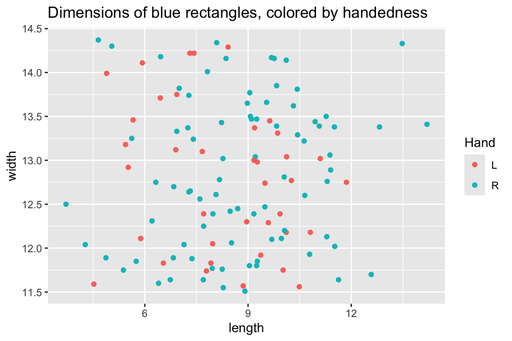

```r
ggplot(df |> filter(color=='blue'))+
  geom_point(aes(x=length,y=width,col=Hand))+
  ggtitle("Dimensions of blue rectangles, colored by handedness")
```

Not much association to see here!

# Practice Problems

Solutions are provided below to be consulted only after working on these questions yourself.

> **a)** *Frequency Distributions* with `table()`. What proportion of rectangles are lefties? What proportion of rectangles in the Northwest are lefties?

> **b)** *Frequency Distributions* with histograms. Make a histogram of all rectangle widths. Does this plot support the decision to replace all missing widths with the mean width?

> **c)** *Summary Statistics.* Find the mean width, mean length, and mean area of the rectangles. Also find the standard deviation for each of these variables. Which variable has the most variation?

> **d)** *Means by group.* with `group_by()`. Do lefties tend to have larger area than righties? Find the average area for rectangles in each group.

> **e)** *Two-way tables.* Is there an association between region and handedness? Perhaps a two-way table could be a useful table here since we’re considering association between two categorical variables.

> **f)** *Square Factor.* Use the code below to create a new column that measures how close to **square** a rectangle is. Then produce a scatter plot of $x$ = perimeter vs $y$ = area, coloring the points according to the squareness variable. What information does this coloring provide? Take some time to consider this question, thinking about geometry and calculus I optimization problems if you’ve done that sort of thing.

```r
rect <- rect |>
  mutate(square_factor = pmin(length,width)/pmax(length,width))
```

# Practice Solutions

> **a)** *Frequency Distributions* with `table()`. What proportion of rectangles are lefties? What proportion of rectangles in the Northwest are lefties?

`table()` gives counts:

```r
table(df$Hand)
```

```
##
##   L   R
## 174 426
```

And the following gives proportions:

```r
prop.table(table(df$Hand))
```

```
##
##    L    R
## 0.29 0.71
```

For the second question, we first filter to restrict to rectangles from the northwest:

```r
nw <- df |> filter(region == 'nw')
round(prop.table(table(nw$Hand)),3)
```

```
##
##     L     R
## 0.314 0.686
```

Higher percentage of lefties in the great NW than overall!

> **b)** *Frequency Distributions* with histograms. Make a histogram of all rectangle widths. Does this plot support the decision to replace all missing widths with the mean width?

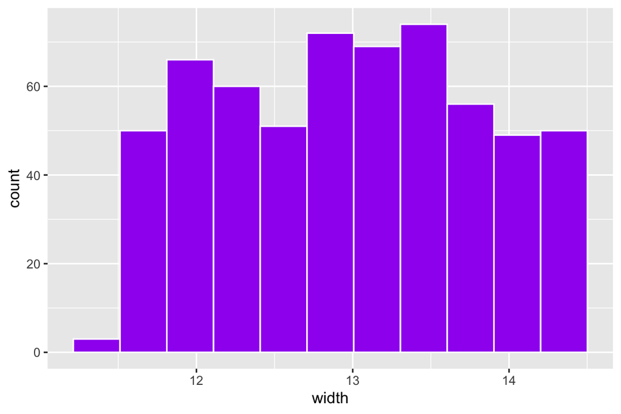

```r
ggplot(df)+
  geom_histogram(aes(x=width),bins=11,col='white',fill='purple')
```

The distribution looks fairly uniform, over a small range (11 to 15 ish), so it’s reasonable to expect that the missing width values would be close to the average of them all.

> **c)** *Summary Statistics.* Find the mean width, mean length, and mean area of the rectangles. Also find the standard deviation for each of these variables. Which variable has the most variation?

We can tackle this by executing each value directly, or we can streamline the process with the `apply()` function, which applies a function to margins (rows = 1, columns = 2) of a data frame.

Means:

```r
apply(df |> select(width,length,area),
      MARGIN = 2,
      FUN = mean)
```

```
##     width    length      area
##  12.98125   8.93265 115.85473
```

Standard Deviations:

```r
apply(df |> select(width,length,area),2,sd)
```

```
##      width     length       area
##  0.8321452  2.0518735 27.2558086
```

Area has the largest standard deviation by far, but it also has the largest mean. We might also want to consider the *coefficient of variation* (discussed on p. 22 of our text), which is defined to be stdev/mean.

The coefficient of variation for length, width, and area are:

```r
apply(df |> select(width,length,area),2,sd)/apply(df |> select(width,length,area),2,mean)
```

```
##      width     length       area
## 0.06410362 0.22970490 0.23525849
```

Even by this measure the area has the most variation, narrowly greater than the length variation.

> **d)** *Means by group.* with `group_by()`. Do lefties tend to have larger area than righties? Find the average area for rectangles in each group.

```r
df |> group_by(Hand) |> summarize(avg = mean(area))
```

```
## # A tibble: 2 × 2
##   Hand    avg
##   <chr> <dbl>
## 1 L      116.
## 2 R      116.
```

> **e)** *Two-way tables.* Is there an association between region and handedness? Perhaps a two-way table could be a useful table here since we’re considering association between two categorical variables.

```r
table(df$Hand,df$region)
```

```
##
##     mw ne nw se sw
##   L 38 33 38 33 32
##   R 86 92 83 83 82
```

Instead of counts, we can display proportions by column (margin = 2) or by row (margin = 1). If we want to compare proportions of righties in each region, we want margin = 2.

```r
prop.table(table(df$Hand,df$region),margin=2)
```

```
##
##            mw        ne        nw        se        sw
##   L 0.3064516 0.2640000 0.3140496 0.2844828 0.2807018
##   R 0.6935484 0.7360000 0.6859504 0.7155172 0.7192982
```

Those proportions all appear fairly close. Visuals can complement tables nicely.

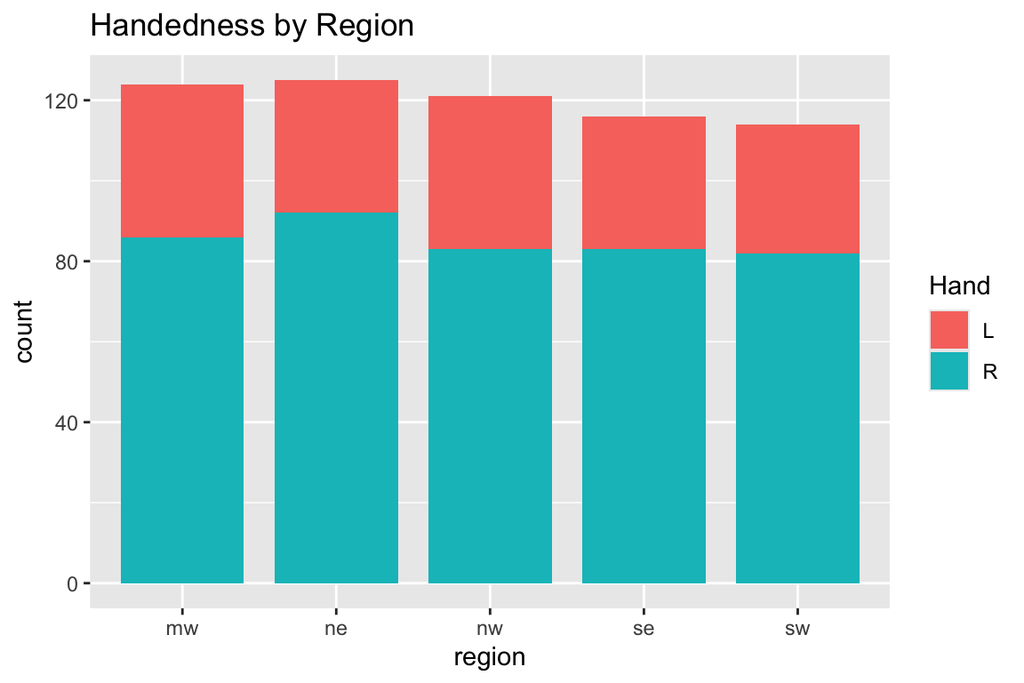

```r
ggplot(df)+
  geom_bar(position='stack',aes(x=region,fill=Hand),width=.8)+
  ggtitle('Handedness by Region')
```

We can also focus on proportions, not total counts in a bar plot

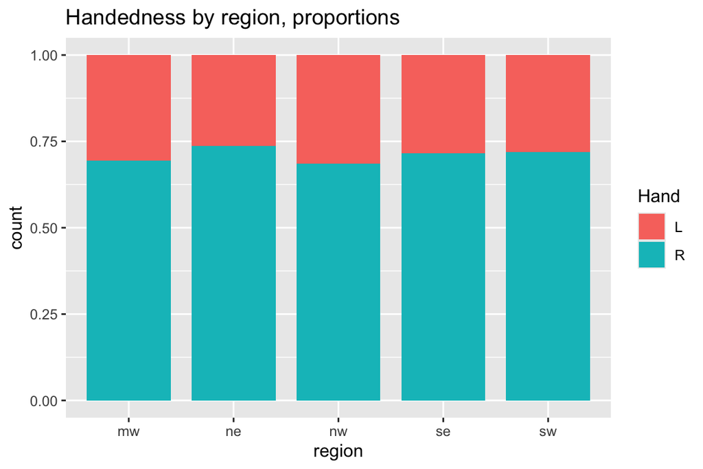

```r
ggplot(df)+
  geom_bar(position='fill',aes(x=region,fill=Hand),width=.8)+
  ggtitle('Handedness by region, proportions')
```

> **f)** *Square Factor.* Use the code below to create a new column that measures how close to **square** a rectangle is. Then produce a scatter plot of $x$ = perimeter vs $y$ = area, coloring the points according to the squareness variable. What information does this coloring provide? Take some time to consider this question, thinking about geometry and calculus I optimization problems if you’ve done that sort of thing.

```r
df <- df |> mutate(square_factor = pmin(length,width)/pmax(length,width))
```

What exactly *is* this square factor? For any rectangle, its square factor is obtained by dividing the smaller side by the larger side. It will always be between 0 and 1. It will equal 1 if and only if the length equals the width of the rectangle (i.e., it is a square). So, the closer the square_factor is to 1, the closer the rectangle is to being a square.

Ok, so how does the code above determine the square factor for each rectangle in the data set?

While the functions `min()` and `max()` produce the min and max of a list of numbers:

```r
min(c(1,20,5,6))
```

```
## [1] 1
```

```r
max(c(1,20,5,6))
```

```
## [1] 20
```

The functions `pmin()` and `pmax()` provide element-wise mins and maxs of multiple vectors.

```r
pmin(c(5,5,5),c(2,5,8),c(10,5,0))
```

```
## [1] 2 5 0
```

```r
pmax(c(5,5,5),c(2,5,8),c(10,5,0))
```

```
## [1] 10  5  8
```

Now, for the plot:

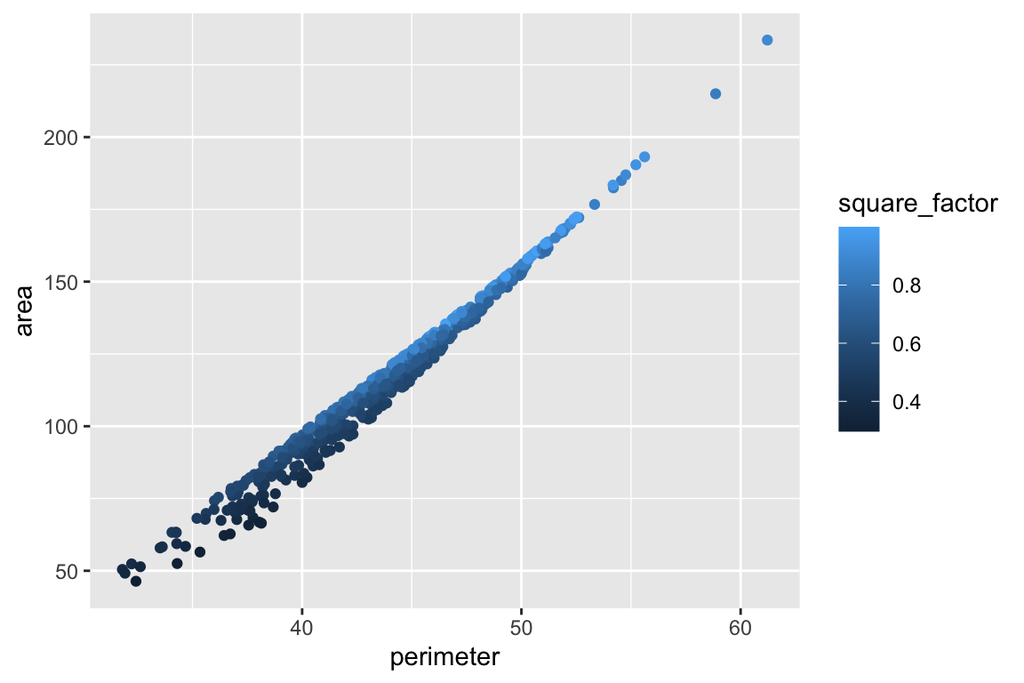

```r
ggplot(df,aes(x=perimeter,y=area,col=square_factor))+geom_point()
```

Notice that for rectangles of a fixed perimeter, the area tends to be larger the closer the rectangle is to being square!

# Resourcees

- [dplyr](https://dplyr.tidyverse.org/)
- [KableExtra for html](https://cran.r-project.org/web/packages/kableExtra/vignettes/awesome_table_in_html.html)